# Data Sources

# U.S. Bureau of Transportation Statistics

The U.S. Bureau of Transportation Statistics (BTS) is a prominent agency within the United States Department of Transportation. Established to provide comprehensive and objective transportation statistics, the BTS plays a crucial role in collecting, analyzing, and disseminating data related to various modes of transportation. This includes air, water, rail, and road transport, as well as aspects like freight movement, passenger travel, and economic indicators within the transportation sector. By offering reliable and up-to-date information, the BTS serves as a valuable resource for policymakers, researchers, and the general public, contributing to informed decision-making and a deeper understanding of the nation’s transportation landscape. You can access this data at [website](https://www.bts.gov/).

**Source** [download data](https://data.bts.gov/Research-and-Statistics/Monthly-Transportation-Statistics/crem-w557/explore)

## Sector 1: Moving Goods in the United States

### Value of shipments by transportation mode

```r
df1 <- read.csv("data/clean_data/11value_us.csv")
#df1$Year <- as.Date(ISOdate(df1$Year, 1, 1))
head(df1)
```

```
                         Mode              Measure.Names Year Trade.Type
1           Other and Unknown Value (billions of 2017 $) 2017     Import
2                    Pipeline Value (billions of 2017 $) 2017     Import
3 Multiple Dms Modes and Mail Value (billions of 2017 $) 2017     Import
4    Air (includes truck-air) Value (billions of 2017 $) 2017     Import
5                       Water Value (billions of 2017 $) 2017     Import
6                        Rail Value (billions of 2017 $) 2017     Import
  Measure.Values
1       11.84428
2       63.44107
3     1037.25672
4      571.16543
5      120.53570
6      113.05147
```

### Weight of shipments by transportation mode

```r
df2 <- read.csv("data/clean_data/12weight_us.csv")
head(df2)
```

```
  Trade.Type                        Mode Year   Measure.Names Measure.Values
1   Domestic    Air (includes truck-air) 2021 Tons (millions)       2.062421
2   Domestic    Air (includes truck-air) 2020 Tons (millions)       2.049576
3   Domestic    Air (includes truck-air) 2019 Tons (millions)       2.126921
4   Domestic    Air (includes truck-air) 2018 Tons (millions)       2.162104
5   Domestic    Air (includes truck-air) 2017 Tons (millions)       2.136208
6   Domestic Multiple Dms Modes and Mail 2021 Tons (millions)     507.931713
```

### Total freight moved by distance

```r
df3 <- read.csv("data/clean_data/13distance_us.csv")
head(df3)
```

```
  Year Distance.band..miles.                                  Measure.Names
1 2017            Over 2,000 % of Total Running Sum of ton-miles (millions)
2 2017         1,500 - 2,000 % of Total Running Sum of ton-miles (millions)
3 2017         1,000 - 1,499 % of Total Running Sum of ton-miles (millions)
4 2017             750 - 999 % of Total Running Sum of ton-miles (millions)
5 2017             500 - 749 % of Total Running Sum of ton-miles (millions)
6 2017             250 - 499 % of Total Running Sum of ton-miles (millions)
  Measure.Values
1      1.0000000
2      0.8880109
3      0.8020772
4      0.6103572
5      0.5091046
6      0.4247276
```

## Sector 2: International Freight

### U.S.-international freight trade by transportation mode

```r
df4 <- read.csv("data/clean_data/21international_value.csv")
head(df4)
```

```
  Year             Mode                  Measure  Trade.Type      Value
1 2017            Water Billions of U.S. Dollars Total trade 1601.74488
2 2017            Truck Billions of U.S. Dollars Total trade  720.82734
3 2017 Total, all modes Billions of U.S. Dollars Total trade 3886.78673
4 2017             Rail Billions of U.S. Dollars Total trade  174.14326
5 2017         Pipeline Billions of U.S. Dollars Total trade   65.24362
6 2017    Other/unknown Billions of U.S. Dollars Total trade  256.06434
```

### Value of U.S.-international freight flows by region and transportation mode

```r
df5 <- read.csv("data/clean_data/22international_Region.csv")
head(df5)
```

```
  Mode Year                                      Measure Region  Value
1  Air 2022 Value of freight flows (millions of dollars)  Other 105226
2  Air 2021 Value of freight flows (millions of dollars)  Other  98610
3  Air 2020 Value of freight flows (millions of dollars)  Other  80459
4  Air 2019 Value of freight flows (millions of dollars)  Other  93690
5  Air 2018 Value of freight flows (millions of dollars)  Other  91088
6  Air 2017 Value of freight flows (millions of dollars)  Other  88959
```

## Sector 3: Contribution to the U.S. Economy

### Gross domestic product (GDP) attributed to transportation by mode

```r
df6 <- read.csv("data/clean_data/31GDP.csv")
head(df6)
```

```
  Year                         Mode      Type Current....billions.
1 2021                    Household Household               411.48
2 2021                     Pipeline Household                   NA
3 2021 Transit and ground passenger Household                   NA
4 2021                        Water Household                   NA
5 2021                         Rail Household                   NA
6 2021                          Air Household                   NA
```

### Monthly transportation employment by mode

```r
df7 <- read.csv("data/clean_data/32monthly_employment.csv")
head(df7)
```

```
                    Date Transportation.Employment...Pipeline.Transportation
1 01/01/2005 12:00:00 AM                                               38100
2 02/01/2005 12:00:00 AM                                               37700
3 03/01/2005 12:00:00 AM                                               37600
4 04/01/2005 12:00:00 AM                                               37800
5 05/01/2005 12:00:00 AM                                               37500
6 06/01/2005 12:00:00 AM                                               37800
  Transportation.Employment...Water.Transportation
1                                            55500
2                                            55100
3                                            56700
4                                            59400
5                                            61100
6                                            62600
  Transportation.Employment...Rail.Transportation
```

[output cut: 27 more lines]

### Average freight revenue per ton-mile

```r
df8 <- read.csv("data/clean_data/33revenue.csv")
head(df8)
```

```
                                       Measure                  Mode Year
1 Freight revenue per ton-mile (current cents) Air carrier, domestic 2021
2 Freight revenue per ton-mile (current cents) Air carrier, domestic 2020
3 Freight revenue per ton-mile (current cents) Air carrier, domestic 2019
4 Freight revenue per ton-mile (current cents) Air carrier, domestic 2018
5 Freight revenue per ton-mile (current cents) Air carrier, domestic 2017
6 Freight revenue per ton-mile (current cents) Air carrier, domestic 2016
     Value
1  97.8600
2 122.9800
3 137.6700
4 137.4876
5 125.1505
6 119.8993
```

### Monthly diesel and jet fuel prices

```r
df9 <- read.csv("data/clean_data/34monthly_fuel_prices.csv")
head(df9)
```

```
  Month.of.Date  Diesel Jet.Fuel
1  January 2000 $135.60   $78.10
2 February 2000 $146.10   $78.00
3    March 2000 $147.90   $77.10
4    April 2000 $142.20   $71.90
5      May 2000 $142.00   $76.20
6     June 2000 $142.10   $78.50
```

### Monthly Freight Transportation Services Index (TSI)

```r
df10 <- read.csv("data/clean_data/35monthly_TSI.csv")
head(df10)
```

```
                    Date Transportation.Services.Index...Freight
1 01/01/2000 12:00:00 AM                                   105.1
2 02/01/2000 12:00:00 AM                                   103.3
3 03/01/2000 12:00:00 AM                                    99.7
4 04/01/2000 12:00:00 AM                                    97.9
5 05/01/2000 12:00:00 AM                                    98.8
6 06/01/2000 12:00:00 AM                                    99.7
```

# Yahoo Stocks Data

Yahoo! Finance, a media property within the Yahoo! network, is a comprehensive platform offering financial news, data, commentary, stock quotes, press releases, financial reports, and original content. Not only does it furnish online tools for personal finance management, but it also publishes both partner content and original stories by its in-house journalists. Holding the 20th position in SimilarWeb’s major news and media websites ranking, Yahoo! Finance has been a prominent player in delivering financial information. In 2017, the platform expanded its coverage to include cryptocurrency news, providing insights into more than 9,000 unique coins, including popular ones like Bitcoin and Ethereum. [website](https://finance.yahoo.com/)

## Sector 4: Changes in the Most Vital Stocks

```r
library(quantmod)
library(tidyquant)
library(ggplot2)
library(plotly)
library(ggfortify)
options("getSymbols.warning4.0"=FALSE)
options("getSymbols.yahoo.warning"=FALSE)

tickers = c("UPS","UNP","JBHT","KEX")
for (i in tickers){
  getSymbols(i,
             from = "2017-01-01",
             to = "2023-12-31")}

x <- list(
  title = "date"
)
y <- list(
  title = "value"
)

stock <- data.frame(UPS$UPS.Adjusted,
                    UNP$UNP.Adjusted,
                    JBHT$JBHT.Adjusted,
                    KEX$KEX.Adjusted
                    )


stock <- data.frame(stock,rownames(stock))
colnames(stock) <- append(tickers,'Dates')

stock$date<-as.Date(stock$Dates,"%Y-%m-%d")
(head(stock))
```

```
                UPS      UNP     JBHT   KEX      Dates       date
2017-01-03 91.09904 87.50710 90.74685 66.25 2017-01-03 2017-01-03
2017-01-04 91.12280 88.03630 91.73150 67.90 2017-01-04 2017-01-04
2017-01-05 91.17026 87.17420 91.14069 68.00 2017-01-05 2017-01-05
2017-01-06 91.35236 88.07900 91.60959 68.30 2017-01-06 2017-01-06
2017-01-09 90.85365 87.42175 90.84063 65.45 2017-01-09 2017-01-09
2017-01-10 90.18076 88.27531 91.63772 64.90 2017-01-10 2017-01-10
```

# World Health Organization: Coronavirus (COVID-19)

The COVID-19 dashboard by the World Health Organization (WHO) offers daily updates on official counts of COVID-19 cases, deaths, and vaccine utilization reported by various countries, territories, and areas. This interactive dashboard serves as a dynamic resource for data visualization, dissemination, and exploration, providing users with regularly updated information. Additionally, it facilitates access to other valuable and informative resources related to the COVID-19 pandemic.

**Source** [COVID-19 data](https://github.com/owid/covid-19-data/tree/master/public/data)

**COVID-19 New Cases and Total Cases in the U.S.**

```r
covid = read.csv("./data/clean_data/covid.csv",header =TRUE, sep = ',')
covid$date <- as.Date(covid$date)
covid$new_cases_per_million <- as.double(covid$new_cases_per_million)
covid$total_cases_per_million <- as.double(covid$total_cases_per_million)
head(covid)
```

```
       location       date total_cases_per_million new_cases_per_million
1 United States 2020-01-05                      NA                 0.000
2 United States 2020-01-12                      NA                 0.000
3 United States 2020-01-19                      NA                 0.000
4 United States 2020-01-26                   0.021                 0.021
5 United States 2020-02-02                   0.027                 0.006
6 United States 2020-02-09                   0.059                 0.033
```

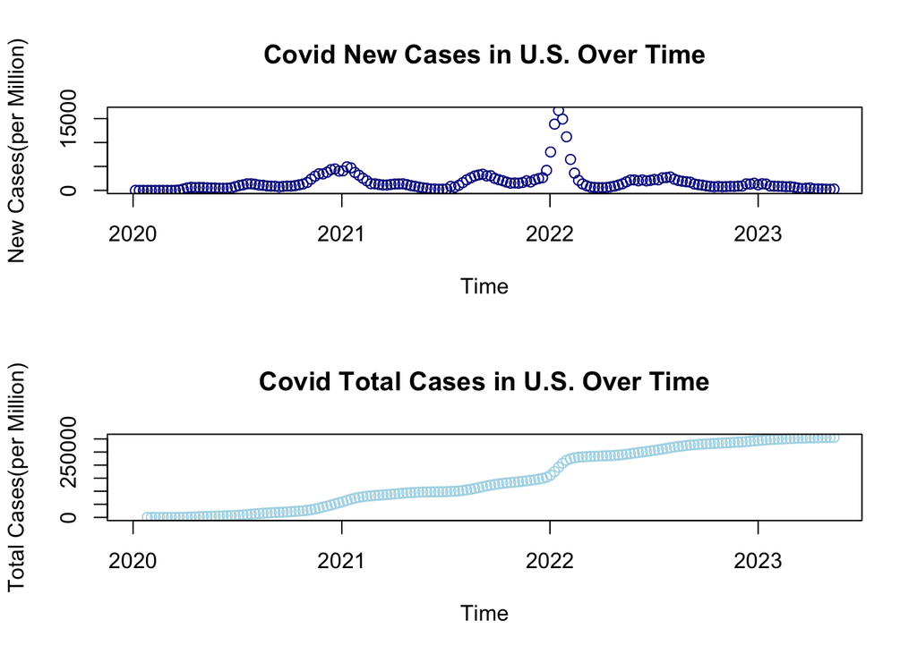

```r
par(mfrow = c(2, 1))
plot1 = plot(covid$date, covid$new_cases_per_million, col="darkblue", xlab="Time", ylab="New Cases(per Million)")
title("Covid New Cases in U.S. Over Time")

plot2 = plot(covid$date, covid$total_cases_per_million, col="lightblue", xlab="Time", ylab="Total Cases(per Million)")
title("Covid Total Cases in U.S. Over Time")
```

Back to top